# Statistische Inferenz und Regressionsanalyse

# Lineare Regression mit infer: Resampling-Methode

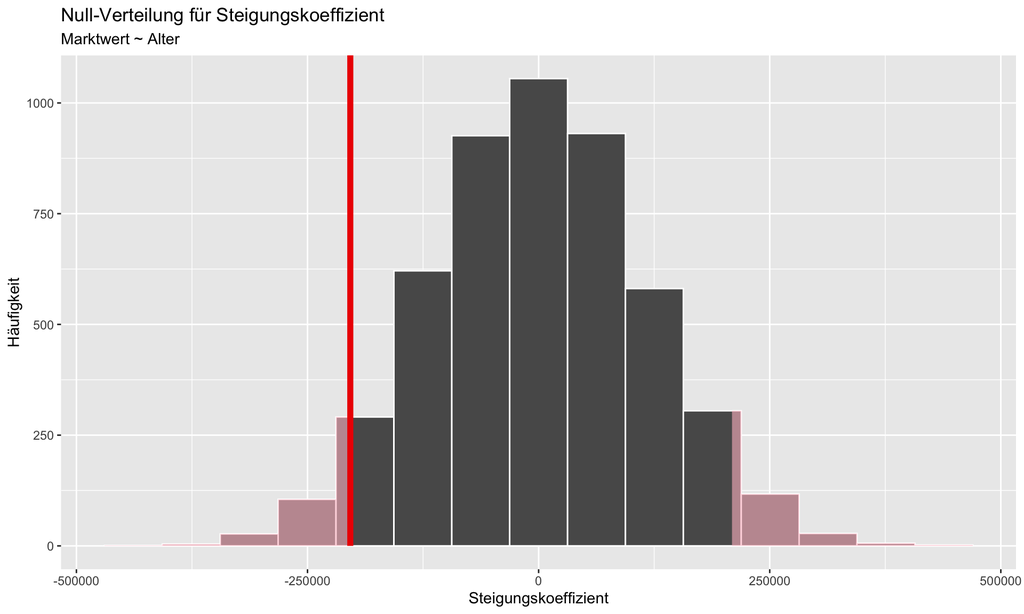

```r
# Resampling für Regressionskoeffizient
# Nullverteilung aufbauen
set.seed(23)

null_slopes <- tbl_buli %>%
  drop_na(mv, age) %>%
  specify(mv ~ age) %>%
  hypothesize(null = "independence") %>%
  generate(reps = 5000, type = "permute") %>%
  calculate(stat = "slope")

# Beobachteter Slope
obs_slope <- tbl_buli %>%
  drop_na(mv, age) %>%
  specify(mv ~ age) %>%
  calculate(stat = "slope")

# Visualisierung
null_slopes %>%
  visualize(method = "simulation") +  # Nur resampling-basierte Nullverteilung anzeigen
  shade_p_value(obs_stat = obs_slope$stat, direction = "two-sided") +
  labs(
    title = "Null-Verteilung für Steigungskoeffizient",
    subtitle = "Marktwert ~ Alter",
    x = "Steigungskoeffizient",
    y = "Häufigkeit"
  )
```

# p-Wert Berechnung für Regression mit infer

```r
# Berechne den kompletten Fit für das beobachtete Modell
obs_slope <- lm(mv ~ age, data = tbl_buli %>% drop_na(mv, age))

# Extrahiere den Steigungskoeffizienten für 'age' aus dem Modellsummary
obs_stat <- summary(obs_slope)$coefficients["age", "t value"]

# p-Wert berechnen
p_value_reg <- null_slopes %>%
  get_p_value(obs_stat = obs_stat, direction = "two-sided")

# Ergebnisse anzeigen
p_value_reg %>%
  gt() %>%
  fmt_number(columns = "p_value", decimals = 4) %>%
  cols_label(p_value = "p-Wert (zweiseitig)")
```

| p-Wert (zweiseitig) |
| --- |
| 0.9936 |

# Einfache Lineare Regression: Traditionelle Methode

```r
# Lineare Regression
lm_slr <- lm(mv ~ age, data = tbl_buli)
tidy_lm_slr <- tidy(lm_slr)
glance_lm_slr <- glance(lm_slr)

# Koeffizienten anzeigen
tidy_lm_slr %>%
  gt() %>%
  fmt_number(columns = c("estimate", "std.error", "statistic"), decimals = 2) %>%
  fmt_number(columns = c("p.value"), decimals = 4) %>%
  cols_label(
    term = "Term",
    estimate = "Schätzwert",
    std.error = "Standardfehler",
    statistic = "t-Wert",
    p.value = "p-Wert"
  )
```

| Term | Schätzwert | Standardfehler | t-Wert | p-Wert |
| --- | --- | --- | --- | --- |
| (Intercept) | 12,400,871.12 | 2,869,745.09 | 4.32 | 0.0000 |
| age | −203,727.10 | 113,647.45 | −1.79 | 0.0735 |

# Modellzusammenfassung für einfache Regression

```r
# Modellzusammenfassung
glance_lm_slr %>%
  select(r.squared, adj.r.squared, sigma, statistic, p.value, AIC, BIC) %>%
  gt() %>%
  fmt_number(columns = c("r.squared", "adj.r.squared", "sigma", "statistic"), decimals = 3) %>%
  fmt_number(columns = c("p.value"), decimals = 4) %>%
  fmt_number(columns = c("AIC", "BIC"), decimals = 1) %>%
  cols_label(
    r.squared = "R²",
    adj.r.squared = "Adjusted R²",
    sigma = "RSE",
    statistic = "F-Statistik",
    p.value = "p-Wert",
    AIC = "AIC",
    BIC = "BIC"
  )
```

| R² | Adjusted R² | RSE | F-Statistik | p-Wert | AIC | BIC |
| --- | --- | --- | --- | --- | --- | --- |
| 0.005 | 0.003 | 13,438,919.437 | 3.213 | 0.0735 | 22,615.7 | 22,629.1 |

# Interpretation des einfachen Regressionsmodells

- **Steigungskoeffizient**: -203727.1 €
  - Mit jedem zusätzlichen Altersjahr ändert sich der Marktwert um diesen Betrag
  - Negativer Koeffizient bedeutet Abnahme des Marktwerts mit zunehmendem Alter
- **Intercept**: 12400871 €
  - Theoretischer Marktwert bei Alter = 0 (hat keine praktische Bedeutung)
- **R²**: 0.005
  - Etwa 0.5% der Variation im Marktwert wird durch das Alter erklärt

# Multiple Regression: Visualisierung

Zusammenhang zwischen Alter, Position und Marktwert

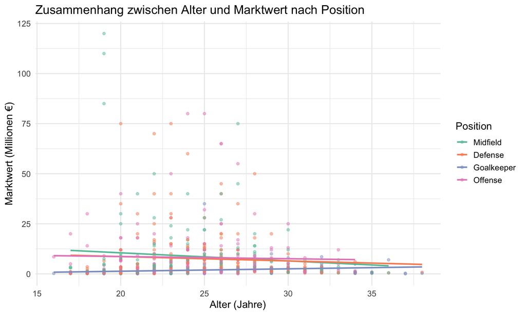

```r
# Visualisierung des Zusammenhangs zwischen Alter und Marktwert, gruppiert nach Position
tbl_buli %>%
  drop_na(pos_cat) %>%
  mutate(
    mv_mio = mv / 1000000,
    pos_cat = fct_relevel(pos_cat, "Midfield")
  ) %>%
  ggplot(aes(x = age, y = mv_mio, color = pos_cat)) +
  geom_point(alpha = 0.5) +
  geom_smooth(method = "lm", se = FALSE) +
  scale_color_brewer(palette = "Set2") +
  labs(
    title = "Zusammenhang zwischen Alter und Marktwert nach Position",
    x = "Alter (Jahre)",
    y = "Marktwert (Millionen €)",
    color = "Position"
  ) +
  theme_minimal(base_size = 14)
```

# Parallel Slopes Model

```r
# Parallel Slopes Model
lm_parallel <- lm(mv ~ age + pos_cat, data = tbl_buli %>% mutate(pos_cat = fct_relevel(pos_cat, "Midfield")))
tidy_lm_parallel <- tidy(lm_parallel)
glance_lm_parallel <- glance(lm_parallel)

# Koeffizienten anzeigen
tidy_lm_parallel %>%
  gt() %>%
  fmt_number(columns = c("estimate", "std.error", "statistic"), decimals = 2) %>%
  fmt_number(columns = c("p.value"), decimals = 4) %>%
  cols_label(
    term = "Term",
    estimate = "Schätzwert",
    std.error = "Standardfehler",
    statistic = "t-Wert",
    p.value = "p-Wert"
  )
```

| Term | Schätzwert | Standardfehler | t-Wert | p-Wert |
| --- | --- | --- | --- | --- |
| (Intercept) | 12,738,116.18 | 2,944,999.12 | 4.33 | 0.0000 |
| age | −164,335.92 | 113,172.18 | −1.45 | 0.1470 |
| pos_catDefense | −1,062,282.24 | 1,374,979.14 | −0.77 | 0.4401 |
| pos_catGoalkeeper | −6,457,886.54 | 1,814,274.53 | −3.56 | 0.0004 |
| pos_catOffense | −538,657.32 | 1,437,315.59 | −0.37 | 0.7080 |

# Parallel Slopes: Visualisierung

```r
# Visualisierung des Parallel Slopes Modells
get_regression_table(lm_parallel) %>%
  select(term, estimate) %>%
  mutate(term = case_when(
    term == "(Intercept)" ~ "Intercept (Midfield)",
    term == "age" ~ "Steigung (Alter)",
    term == "pos_catDefense" ~ "Defense vs. Midfield",
    term == "pos_catGoalkeeper" ~ "Goalkeeper vs. Midfield",
    term == "pos_catOffense" ~ "Offense vs. Midfield",
    TRUE ~ term
  )) %>%
  gt() %>%
  fmt_number(columns = "estimate", decimals = 2) %>%
  cols_label(
    term = "Parameter",
    estimate = "Schätzwert"
  )
```

| Parameter | Schätzwert |
| --- | --- |
| intercept | 12,738,116.18 |
| Steigung (Alter) | −164,335.92 |
| pos_cat: Defense | −1,062,282.24 |
| pos_cat: Goalkeeper | −6,457,886.54 |
| pos_cat: Offense | −538,657.32 |

# Interaction Model

```r
# Interaktionsmodell
lm_interaction <- lm(mv ~ age * pos_cat, data = tbl_buli %>% mutate(pos_cat = fct_relevel(pos_cat, "Midfield")))
tidy_lm_interaction <- tidy(lm_interaction)
glance_lm_interaction <- glance(lm_interaction)

# Koeffizienten anzeigen
tidy_lm_interaction %>%
  gt() %>%
  fmt_number(columns = c("estimate", "std.error", "statistic"), decimals = 2) %>%
  fmt_number(columns = c("p.value"), decimals = 4) %>%
  cols_label(
    term = "Term",
    estimate = "Schätzwert",
    std.error = "Standardfehler",
    statistic = "t-Wert",
    p.value = "p-Wert"
  )
```

| Term | Schätzwert | Standardfehler | t-Wert | p-Wert |
| --- | --- | --- | --- | --- |
| (Intercept) | 18,575,629.40 | 5,587,887.49 | 3.32 | 0.0009 |
| age | −403,520.61 | 225,094.04 | −1.79 | 0.0735 |
| pos_catDefense | −5,590,346.59 | 7,737,001.79 | −0.72 | 0.4702 |
| pos_catGoalkeeper | −19,650,777.34 | 8,541,075.48 | −2.30 | 0.0217 |
| pos_catOffense | −7,741,528.24 | 8,007,511.95 | −0.97 | 0.3340 |
| age:pos_catDefense | 186,252.20 | 309,966.96 | 0.60 | 0.5481 |
| age:pos_catGoalkeeper | 523,039.10 | 330,912.29 | 1.58 | 0.1145 |
| age:pos_catOffense | 294,267.51 | 320,228.56 | 0.92 | 0.3585 |

# Modellvergleich: Parallel Slopes vs. Interaction

```r
# Modellvergleich
anova_models <- anova(lm_parallel, lm_interaction)

# Ergebnisse anzeigen
anova_models %>%
  as_tibble() %>%
  gt() %>%
  fmt_number(columns = c("RSS", "Sum of Sq", "F"), decimals = 2) %>%
  fmt_number(columns = c("Pr(>F)"), decimals = 4) %>%
  cols_label(
    Res.Df = "Residual DF",
    RSS = "Residual Sum of Squares",
    Df = "DF",
    `Sum of Sq` = "Sum of Squares",
    F = "F-Wert",
    `Pr(>F)` = "p-Wert"
  )
```

| Residual DF | Residual Sum of Squares | DF | Sum of Squares | F-Wert | p-Wert |
| --- | --- | --- | --- | --- | --- |
| 629 | 111,635,582,739,428,688.00 | NA | NA | NA | NA |
| 626 | 111,170,519,823,012,736.00 | 3 | 465,062,916,415,952.00 | 0.87 | 0.4548 |

# Visualisierung des Interaktionsmodells

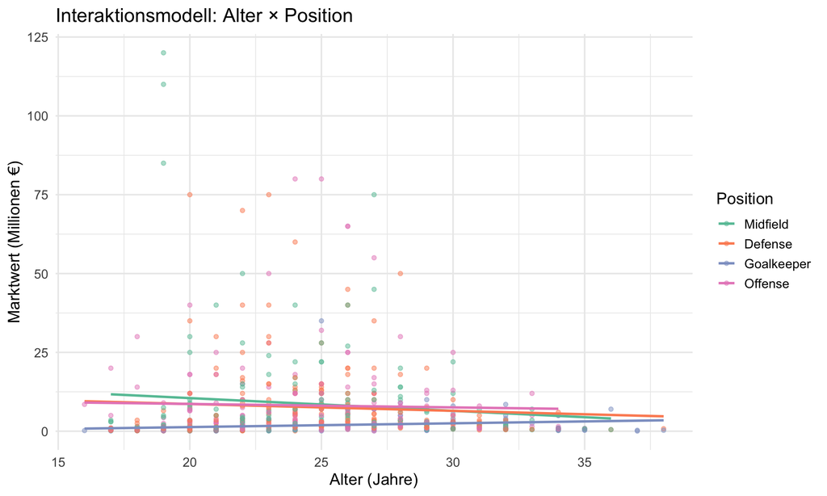

```r
# Visualisierung des Interaktionsmodells
tbl_buli %>%
  drop_na(age, pos_cat) %>%  # Entferne NA-Werte für die relevanten Variablen
  mutate(
    mv_mio = mv / 1000000,
    pos_cat = fct_relevel(pos_cat, "Midfield"),
    fitted_values = predict(lm_interaction, newdata = .) / 1000000  # Vorhersagen basierend auf den gefilterten Daten
  ) %>%
  ggplot() +
  geom_point(aes(x = age, y = mv_mio, color = pos_cat), alpha = 0.5) +
  geom_line(aes(x = age, y = fitted_values, color = pos_cat), size = 1) +
  scale_color_brewer(palette = "Set2") +
  labs(
    title = "Interaktionsmodell: Alter × Position",
    x = "Alter (Jahre)",
    y = "Marktwert (Millionen €)",
    color = "Position"
  ) +
  theme_minimal(base_size = 14)
```

# BLUE: Best Linear Unbiased Estimator

Die OLS-Regression (Ordinary Least Squares) liefert BLUE-Schätzer, wenn folgende Gauss-Markov-Annahmen erfüllt sind:

1. **Linearität**: Die Beziehung zwischen X und Y ist linear
2. **Unverzerrtheit**: Der Erwartungswert der Residuen ist Null
3. **Homoskedastizität**: Konstante Varianz der Residuen
4. **Keine Autokorrelation**: Die Residuen sind unabhängig voneinander
5. **Keine perfekte Multikollinearität**: Keine der unabhängigen Variablen kann als lineare Kombination der anderen ausgedrückt werden

Diese Eigenschaften garantieren, dass unsere Schätzer die besten (kleinste Varianz), linearen und unverzerrten Schätzer der wahren Populationsparameter sind.

# Annahmenüberprüfung: Linearität und Homoskedastizität

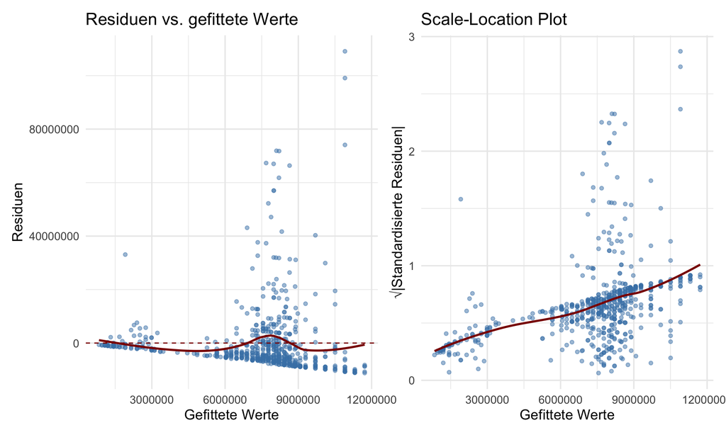

```r
# Residuenplot für Linearitäts- und Homoskedastizitätsannahme
p1 <- augment(lm_interaction) %>%
  ggplot(aes(x = .fitted, y = .resid)) +
  geom_point(alpha = 0.5, color = "steelblue") +
  geom_hline(yintercept = 0, linetype = "dashed", color = "darkred") +
  geom_smooth(method = "loess", se = FALSE, color = "darkred") +
  labs(
    title = "Residuen vs. gefittete Werte",
    x = "Gefittete Werte",
    y = "Residuen"
  ) +
  theme_minimal(base_size = 14)

# Scale-Location Plot für Homoskedastizität
p2 <- augment(lm_interaction) %>%
  ggplot(aes(x = .fitted, y = sqrt(abs(.std.resid)))) +
  geom_point(alpha = 0.5, color = "steelblue") +
  geom_smooth(method = "loess", se = FALSE, color = "darkred") +
  labs(
    title = "Scale-Location Plot",
    x = "Gefittete Werte",
    y = "√|Standardisierte Residuen|"
  ) +
  theme_minimal(base_size = 14)

p1 + p2
```

# Annahmenüberprüfung: Normalverteilung der Residuen

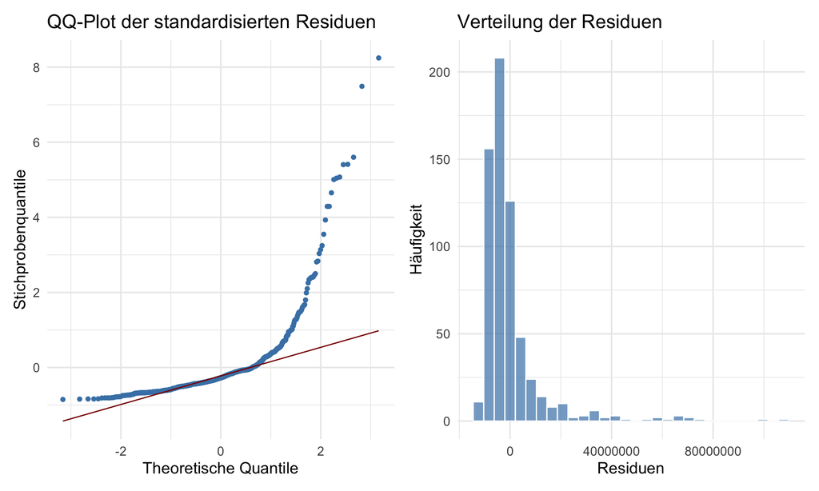

```r
# QQ-Plot für Normalverteilungsannahme
p3 <- augment(lm_interaction) %>%
  ggplot(aes(sample = .std.resid)) +
  geom_qq(color = "steelblue") +
  geom_qq_line(color = "darkred") +
  labs(
    title = "QQ-Plot der standardisierten Residuen",
    x = "Theoretische Quantile",
    y = "Stichprobenquantile"
  ) +
  theme_minimal(base_size = 14)

# Histogramm der Residuen
p4 <- augment(lm_interaction) %>%
  ggplot(aes(x = .resid)) +
  geom_histogram(bins = 30, fill = "steelblue", color = "white", alpha = 0.7) +
  labs(
    title = "Verteilung der Residuen",
    x = "Residuen",
    y = "Häufigkeit"
  ) +
  theme_minimal(base_size = 14)

p3 + p4
```

# Annahmenüberprüfung: Multikollinearität

```r
# VIF-Werte berechnen
vif_values <- car::vif(lm_interaction)

# VIF-Werte als Tabelle darstellen
data.frame(
  Variable = rownames(vif_values),
  VIF = vif_values[, "GVIF^(1/(2*Df))"]  # Zugriff auf die richtige Spalte
) %>%
  gt() %>%
  fmt_number(columns = "VIF", decimals = 2) %>%
  cols_label(
    Variable = "Variable",
    VIF = "VIF-Wert"
  ) %>%
  tab_header(
    title = "Varianzinflationsfaktoren (VIF)"
  )
```

Varianzinflationsfaktoren (VIF)

| Variable | VIF-Wert |
| --- | --- |
| age | 2.00 |
| pos_cat | 5.25 |
| age:pos_cat | 5.36 |

# Annahmenverletzung: Nicht-Linearität

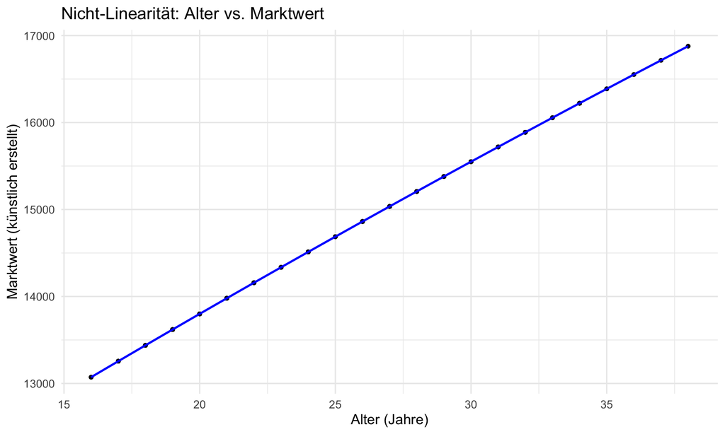

```r
# Künstlicher quadratischer Zusammenhang
set.seed(123)
tbl_nonlinear <- tbl_buli %>%
  mutate(
    mv_quadratic = 10000 + 200 * age - 0.5 * age^2  # Quadratischer Zusammenhang erstellen
  )

# Visualisierung der Daten: Alter vs. Marktwert
tbl_nonlinear %>%
  ggplot(aes(x = age, y = mv_quadratic)) +
  geom_point() +
  geom_smooth(method = "lm", formula = y ~ poly(x, 2), se = FALSE, color = "blue") +  # Lineare Regression mit quadratischem Term
  labs(
    title = "Nicht-Linearität: Alter vs. Marktwert",
    x = "Alter (Jahre)",
    y = "Marktwert (künstlich erstellt)"
  ) +
  theme_minimal(base_size = 14)
```

```r
# Lineares Modell ohne Nicht-Linearität
lm_nonlinear <- lm(mv_quadratic ~ age, data = tbl_nonlinear)

# Fitting eines quadratischen Modells
lm_quadratic <- lm(mv_quadratic ~ age + I(age^2), data = tbl_nonlinear)

# Modellvergleich
summary(lm_nonlinear)
```

```
##
## Call:
## lm(formula = mv_quadratic ~ age, data = tbl_nonlinear)
##
## Residuals:
##     Min      1Q  Median      3Q     Max
## -66.275  -9.374   5.461  10.494  11.527
##
## Coefficients:
##               Estimate Std. Error t value            Pr(>|t|)
## (Intercept) 10313.9025     2.6234    3931 <0.0000000000000002 ***
## age           174.4835     0.1043    1674 <0.0000000000000002 ***
## ---
## Signif. codes:  0 '***' 0.001 '**' 0.01 '*' 0.05 '.' 0.1 ' ' 1
##
## Residual standard error: 12.6 on 643 degrees of freedom
## Multiple R-squared:  0.9998, Adjusted R-squared:  0.9998
## F-statistic: 2.801e+06 on 1 and 643 DF,  p-value: < 0.00000000000000022
```

```r
summary(lm_quadratic)
```

```
##
## Call:
## lm(formula = mv_quadratic ~ age + I(age^2), data = tbl_nonlinear)
##
## Residuals:
##               Min                1Q            Median                3Q
## -0.00000000105856 -0.00000000000308 -0.00000000000056  0.00000000000362
##               Max
##  0.00000000005669
##
## Coefficients:
##                            Estimate              Std. Error         t value
## (Intercept)  9999.99999999982719601     0.00000000004260445 234717265706529
## age           200.00000000001102762     0.00000000000340612  58717789156724
## I(age^2)       -0.50000000000022615     0.00000000000006639  -7531467769411
##                        Pr(>|t|)
## (Intercept) <0.0000000000000002 ***
## age         <0.0000000000000002 ***
## I(age^2)    <0.0000000000000002 ***
## ---
## Signif. codes:  0 '***' 0.001 '**' 0.01 '*' 0.05 '.' 0.1 ' ' 1
##
## Residual standard error: 0.00000000004241 on 642 degrees of freedom
## Multiple R-squared:      1,  Adjusted R-squared:      1
## F-statistic: 1.236e+29 on 2 and 642 DF,  p-value: < 0.00000000000000022
```

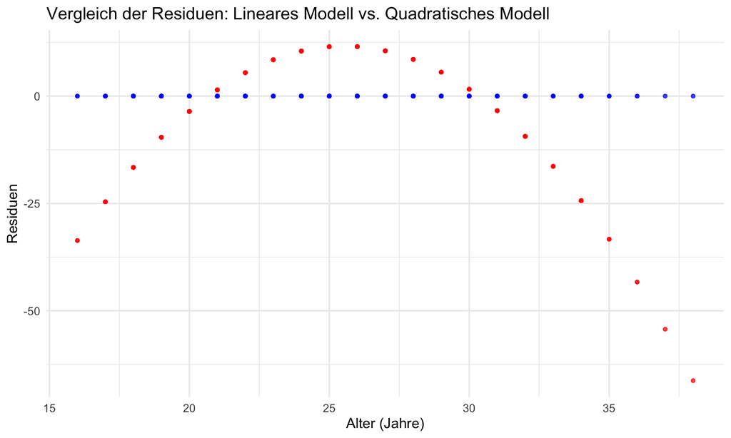

```r
# Residuen der beiden Modelle vergleichen
tbl_nonlinear %>%
  mutate(
    lm_nonlinear_resid = residuals(lm_nonlinear),
    lm_quadratic_resid = residuals(lm_quadratic)
  ) %>%
  ggplot(aes(x = age)) +
  geom_point(aes(y = lm_nonlinear_resid), color = "red", alpha = 0.5) +
  geom_point(aes(y = lm_quadratic_resid), color = "blue", alpha = 0.5) +
  labs(
    title = "Vergleich der Residuen: Lineares Modell vs. Quadratisches Modell",
    x = "Alter (Jahre)",
    y = "Residuen"
  ) +
  theme_minimal(base_size = 14)
```